# 1. Description

## 1.1 Background and Context

AllLife Bank is a US bank that has a growing customer base. The majority of these customers are liability customers (depositors) with varying sizes of deposits. The number of customers who are also borrowers (asset customers) is quite small, and the bank is interested in expanding this base rapidly to bring in more loan business and in the process, earn more through the interest on loans. In particular, the management wants to explore ways of converting its liability customers to personal loan customers (while retaining them as depositors).

A campaign that the bank ran last year for liability customers showed a healthy conversion rate of over 9% success. This has encouraged the retail marketing department to devise campaigns with better target marketing to increase the success ratio.

You as a Data scientist at AllLife bank have to build a model that will help the marketing department to identify the potential customers who have a higher probability of purchasing the loan.

## 1.2 Objective

To predict whether a liability customer will buy a personal loan or not. Which variables are most significant. Which segment of customers should be targeted more.

## 1.3 Data Dictionary

- ID: Customer ID
- Age: Customer’s age in completed years
- Experience: #years of professional experience
- Income: Annual income of the customer (in thousand dollars)
- ZIP Code: Home Address ZIP code.
- Family: the Family size of the customer
- CCAvg: Average spending on credit cards per month (in thousand dollars)
- Education: Education Level. 1: Undergrad; 2: Graduate;3: Advanced/Professional
- Mortgage: Value of house mortgage if any. (in thousand dollars)
- Personal_Loan: Did this customer accept the personal loan offered in the last campaign?
- Securities_Account: Does the customer have securities account with the bank?
- CD_Account: Does the customer have a certificate of deposit (CD) account with the bank?
- Online: Do customers use internet banking facilities?
- CreditCard: Does the customer use a credit card issued by any other Bank (excluding All life Bank)?

# 2. Data Import & Analysis

## 2.1 Import libraries

```python
import pandas as pd
import numpy as np
import matplotlib.pyplot as plt
import seaborn as sns

# Library to split data
from sklearn.model_selection import train_test_split

# To enable plotting graphs in Jupyter notebook
%matplotlib inline
import re as re
import warnings
warnings.filterwarnings("ignore")

# To create linear regression model
from sklearn.linear_model import LinearRegression
from sklearn.linear_model import LogisticRegression
from sklearn.tree import DecisionTreeClassifier
from sklearn import tree

# To check model performance
from sklearn.metrics import mean_absolute_error, mean_squared_error, r2_score

# To get diferent metric scores
from sklearn import metrics
from sklearn.metrics import accuracy_score, recall_score, precision_score, roc_auc_score, roc_curve, confusion_matrix, precision_recall_curve, f1_score
from sklearn.model_selection import GridSearchCV
```

## 2.2 Load data from the CSV file

```python
loan = pd.read_csv("Loan_Modelling.csv")
```

## 2.3 Shape of data

```python
loan.head(10)
```

|  | ID | Age | Experience | Income | ZIPCode | Family | CCAvg | Education | Mortgage | Personal_Loan | Securities_Account | CD_Account | Online | CreditCard |
| --- | --- | --- | --- | --- | --- | --- | --- | --- | --- | --- | --- | --- | --- | --- |
| 0 | 1 | 25 | 1 | 49 | 91107 | 4 | 1.6 | 1 | 0 | 0 | 1 | 0 | 0 | 0 |
| 1 | 2 | 45 | 19 | 34 | 90089 | 3 | 1.5 | 1 | 0 | 0 | 1 | 0 | 0 | 0 |
| 2 | 3 | 39 | 15 | 11 | 94720 | 1 | 1.0 | 1 | 0 | 0 | 0 | 0 | 0 | 0 |
| 3 | 4 | 35 | 9 | 100 | 94112 | 1 | 2.7 | 2 | 0 | 0 | 0 | 0 | 0 | 0 |
| 4 | 5 | 35 | 8 | 45 | 91330 | 4 | 1.0 | 2 | 0 | 0 | 0 | 0 | 0 | 1 |
| 5 | 6 | 37 | 13 | 29 | 92121 | 4 | 0.4 | 2 | 155 | 0 | 0 | 0 | 1 | 0 |
| 6 | 7 | 53 | 27 | 72 | 91711 | 2 | 1.5 | 2 | 0 | 0 | 0 | 0 | 1 | 0 |
| 7 | 8 | 50 | 24 | 22 | 93943 | 1 | 0.3 | 3 | 0 | 0 | 0 | 0 | 0 | 1 |
| 8 | 9 | 35 | 10 | 81 | 90089 | 3 | 0.6 | 2 | 104 | 0 | 0 | 0 | 1 | 0 |
| 9 | 10 | 34 | 9 | 180 | 93023 | 1 | 8.9 | 3 | 0 | 1 | 0 | 0 | 0 | 0 |

```python
loan.shape
```

```
(5000, 14)
```

### Observations on shape:

Data set has 5000 rows and 14 data attributes

## 2.4 Check for duplicate data

```python
loan[loan.duplicated()].count()
```

```
ID                    0
Age                   0
Experience            0
Income                0
ZIPCode               0
Family                0
CCAvg                 0
Education             0
Mortgage              0
Personal_Loan         0
Securities_Account    0
CD_Account            0
Online                0
CreditCard            0
dtype: int64
```

### Observations on duplicates

There are no duplicate rows to worry about

## 2.5 Check type of data

```python
loan.info()
```

```
<class 'pandas.core.frame.DataFrame'>
RangeIndex: 5000 entries, 0 to 4999
Data columns (total 14 columns):
 #   Column              Non-Null Count  Dtype
---  ------              --------------  -----
 0   ID                  5000 non-null   int64
 1   Age                 5000 non-null   int64
 2   Experience          5000 non-null   int64
 3   Income              5000 non-null   int64
 4   ZIPCode             5000 non-null   int64
 5   Family              5000 non-null   int64
 6   CCAvg               5000 non-null   float64
 7   Education           5000 non-null   int64
 8   Mortgage            5000 non-null   int64
 9   Personal_Loan       5000 non-null   int64
 10  Securities_Account  5000 non-null   int64
 11  CD_Account          5000 non-null   int64
 12  Online              5000 non-null   int64
 13  CreditCard          5000 non-null   int64
dtypes: float64(1), int64(13)
memory usage: 547.0 KB
```

### Observations

1. There are no missing values in the data set
2. All attributes are captured as numerical values
3. ZIPCode and Education are categorical attrobutes which are captured as numericals
4. Personal_Loan, Securities_Account, CD_Account, Online & CreditCard are binary values - with 1 representing Yes and 0 representing a No

## 2.6 Statistical summary

```python
loan.describe().T
```

|  | count | mean | std | min | 25% | 50% | 75% | max |
| --- | --- | --- | --- | --- | --- | --- | --- | --- |
| ID | 5000.0 | 2500.500000 | 1443.520003 | 1.0 | 1250.75 | 2500.5 | 3750.25 | 5000.0 |
| Age | 5000.0 | 45.338400 | 11.463166 | 23.0 | 35.00 | 45.0 | 55.00 | 67.0 |
| Experience | 5000.0 | 20.104600 | 11.467954 | -3.0 | 10.00 | 20.0 | 30.00 | 43.0 |
| Income | 5000.0 | 73.774200 | 46.033729 | 8.0 | 39.00 | 64.0 | 98.00 | 224.0 |
| ZIPCode | 5000.0 | 93169.257000 | 1759.455086 | 90005.0 | 91911.00 | 93437.0 | 94608.00 | 96651.0 |
| Family | 5000.0 | 2.396400 | 1.147663 | 1.0 | 1.00 | 2.0 | 3.00 | 4.0 |
| CCAvg | 5000.0 | 1.937938 | 1.747659 | 0.0 | 0.70 | 1.5 | 2.50 | 10.0 |
| Education | 5000.0 | 1.881000 | 0.839869 | 1.0 | 1.00 | 2.0 | 3.00 | 3.0 |
| Mortgage | 5000.0 | 56.498800 | 101.713802 | 0.0 | 0.00 | 0.0 | 101.00 | 635.0 |
| Personal_Loan | 5000.0 | 0.096000 | 0.294621 | 0.0 | 0.00 | 0.0 | 0.00 | 1.0 |
| Securities_Account | 5000.0 | 0.104400 | 0.305809 | 0.0 | 0.00 | 0.0 | 0.00 | 1.0 |
| CD_Account | 5000.0 | 0.060400 | 0.238250 | 0.0 | 0.00 | 0.0 | 0.00 | 1.0 |
| Online | 5000.0 | 0.596800 | 0.490589 | 0.0 | 0.00 | 1.0 | 1.00 | 1.0 |
| CreditCard | 5000.0 | 0.294000 | 0.455637 | 0.0 | 0.00 | 0.0 | 1.00 | 1.0 |

### Observations

1. There are negative values for Yrs or Experience. These need to be dropped from the dat aset
2. Everyone in the dataset has achieved a minimum level of under graduate education
3. Income and mortgage are right skewed distributions with more data points to the right of the median.

# 3. EDA

```python
# While doing uni-variate analysis of numerical variables we want to study their central tendency
# and dispersion.
# Let us write a function that will help us create boxplot and histogram for any input numerical
# variable.
# This function takes the numerical column as the input and returns the boxplots
# and histograms for the variable.
# Let us see if this help us write faster and cleaner code.
def histogram_boxplot(feature, figsize=(15,10), bins = None):
    """ Boxplot and histogram combined
    feature: 1-d feature array
    figsize: size of fig (default (9,8))
    bins: number of bins (default None / auto)
    """
    f2, (ax_box2, ax_hist2) = plt.subplots(nrows = 2, # Number of rows of the subplot grid= 2
                                           sharex = True, # x-axis will be shared among all subplots
                                           gridspec_kw = {"height_ratios": (.25, .75)},
                                           figsize = figsize
                                           ) # creating the 2 subplots
    sns.boxplot(feature, ax=ax_box2, showmeans=True, color='violet') # boxplot will be created and a star will indicate the mean value of the column
    sns.distplot(feature, kde=F, ax=ax_hist2, bins=bins,palette="winter") if bins else sns.distplot(feature, kde=False, ax=ax_hist2) # For histogram
    ax_hist2.axvline(np.mean(feature), color='green', linestyle='--') # Add mean to the histogram
    ax_hist2.axvline(np.median(feature), color='black', linestyle='-') # Add median to the histogram

def perc_on_bar(plot, feature):
    '''
    plot
    feature: categorical feature
    the function won't work if a column is passed in hue parameter
    '''
    total = len(feature) # length of the column
    for p in ax.patches:
        percentage = '{:.1f}%'.format(100 * p.get_height()/total) # percentage of each class of the category
        x = p.get_x() + p.get_width() / 2 - 0.05 # width of the plot
        y = p.get_y() + p.get_height()           # hieght of the plot
        ax.annotate(percentage, (x, y), size = 12) # annotate the percantage
    plt.show() # show the plot
```

## 3.1 Univariate analysis

### Age

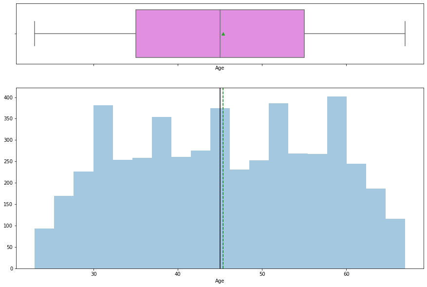

```python
histogram_boxplot(loan["Age"])
```

#### Observations on Age

1. Age seems to be somewhat of a normally distributed data set. There are some spikes in distributions around the 30, 40, 50 and 60 age marks.
2. Box plot reveals that there are no severe outliers

### Experience

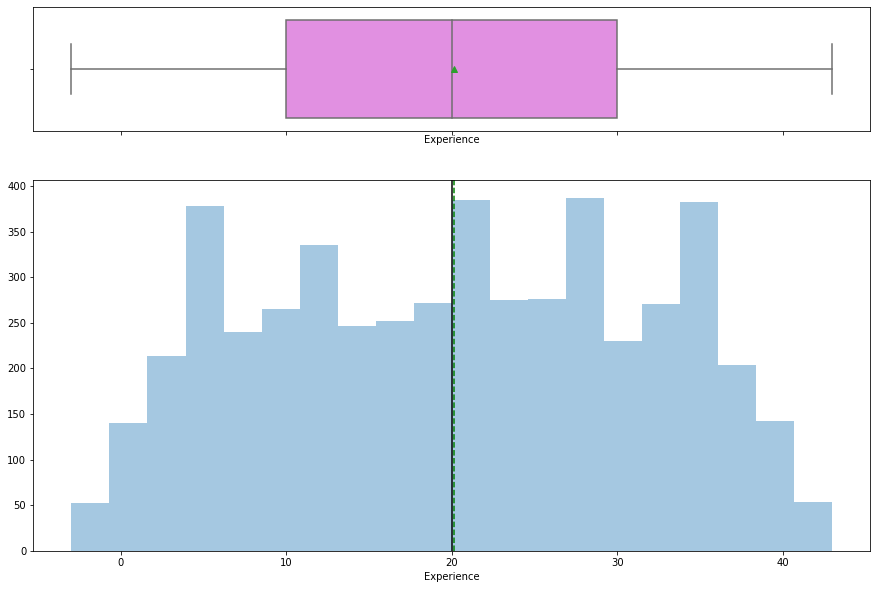

```python
histogram_boxplot(loan["Experience"])
```

#### Observations on Experience

1. Experience seems to be somewhat of a normally distributed data set. There are some spikes in distributions coniciding Age around the 30, 40, 50 and 60 marks. This is a fresh indication of a possible strong linear relationship between Age and Experience. We will address this later in the modelling with analysis of colinearity
2. Box plot reveals that there are no severe outliers and this is not surprising as the Experience data trend seems to closely follow that of Age

### Income

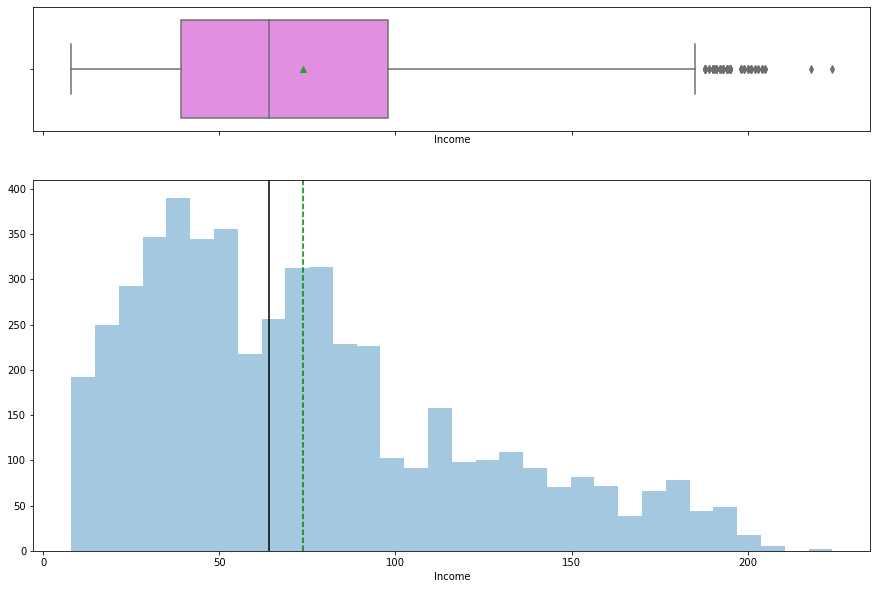

```python
histogram_boxplot(loan["Income"])
```

#### Observations on Income

1. Income is a right skewed distribution as noted above from the describe() function
2. There are a few outliers beyond the IQR ranges on the box plot. We'll have to address this during data preparation before building the model

### Family

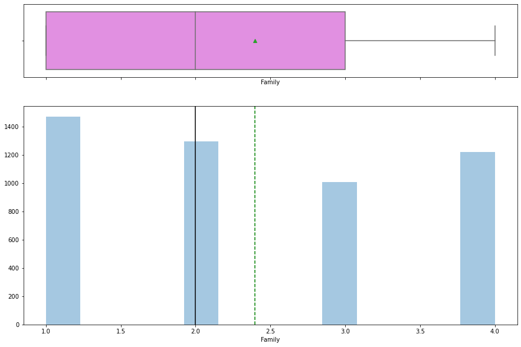

```python
histogram_boxplot(loan["Family"])
```

#### Observations on Family

1. Family size is fairly equally distributed aming 1,2,3,4 family members - this shows a healthy mix for this attribute

### CCAvg

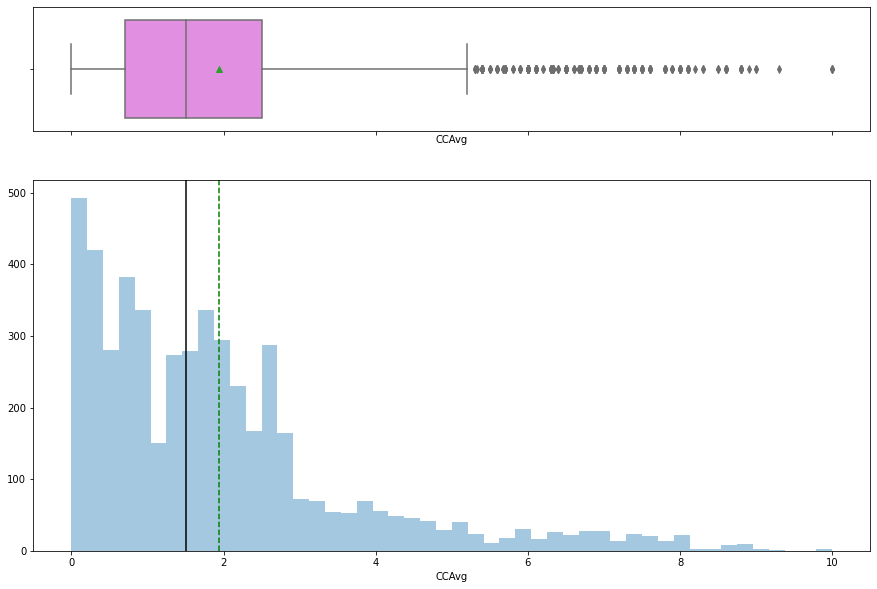

```python
histogram_boxplot(loan["CCAvg"])
```

#### Observations on CCAvg

1. CCAvg seems to be a right skewed distribution
2. CCAvg also looks more linear than normal
3. There are a few outliers

### Mortgage

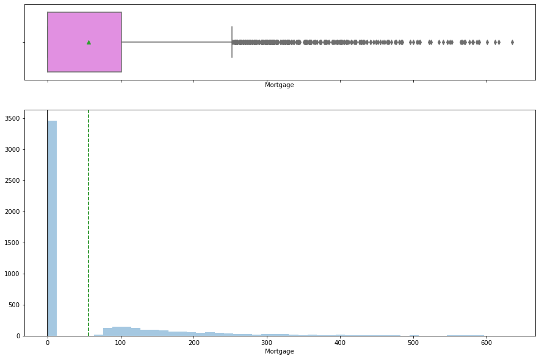

```python
histogram_boxplot(loan["Mortgage"])
```

#### Observations on Mortgage

1. There are quite a few outliers in the data set

### Education

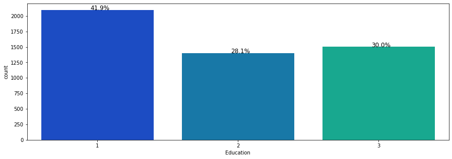

```python
plt.figure(figsize=(15,5))
ax = sns.countplot(loan["Education"],palette='winter')
perc_on_bar(ax,loan["Education"])
```

#### Observations on Education

1. Every customer surveyed in the dataset has some form of college education
2. About 40% have undergraduate and about 60% have post greduate (MS & Advanced combined)

### Securities_Account

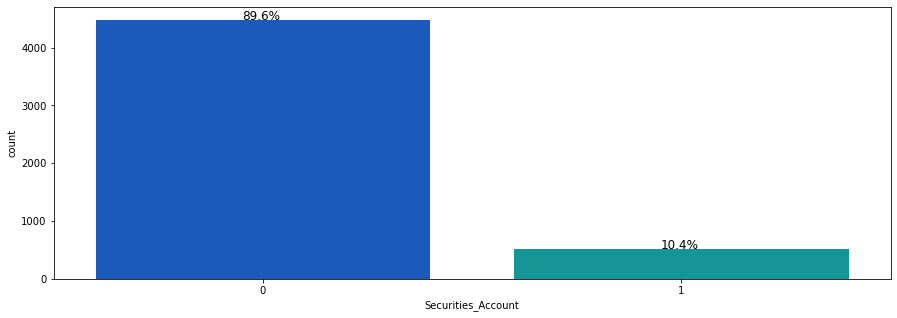

```python
plt.figure(figsize=(15,5))
ax = sns.countplot(loan["Securities_Account"],palette='winter')
perc_on_bar(ax,loan["Securities_Account"])
```

#### Observations on Securities_Account

1. 9 out of 10 customers surveyed dont have a securities account

### CD_Account

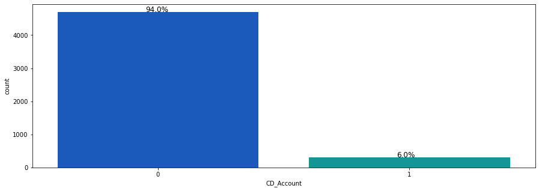

```python
plt.figure(figsize=(15,5))
ax = sns.countplot(loan["CD_Account"],palette='winter')
perc_on_bar(ax,loan["CD_Account"])
```

#### Observations on CD_Account

1. More than 9 out of 10 customers surveyed dont have a CD account

### Online

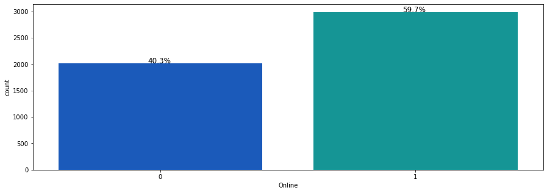

```python
plt.figure(figsize=(15,5))
ax = sns.countplot(loan["Online"],palette='winter')
perc_on_bar(ax,loan["Online"])
```

### Observations on Online

60% of customers have online access to their accounts

### CreditCard

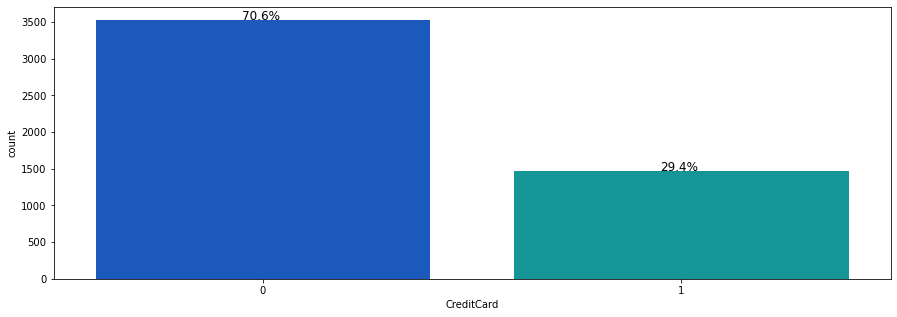

```python
plt.figure(figsize=(15,5))
ax = sns.countplot(loan["CreditCard"],palette='winter')
perc_on_bar(ax,loan["CreditCard"])
```

#### Observations on CreditCard

More than 70% of customers dont have a credit card account with the bank

## 3.2 Bi-Variate analysis

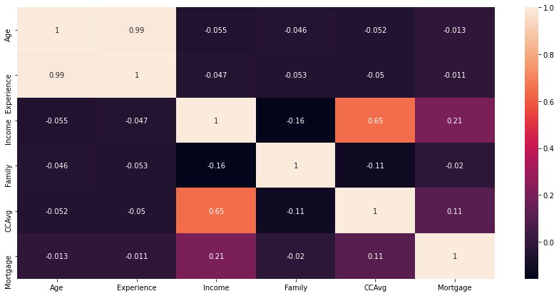

```python
plt.figure(figsize=(15,7))
numerical_cont_columns=['Age','Experience','Income','Family','CCAvg','Mortgage']
corr = loan[numerical_cont_columns].corr()
sns.heatmap(corr,annot=True)
plt.show()
```

### Insights

1. Age and Experience have strong correlation. This is expected. With this high level of correlation, its possible to remove one of them in our model.
2. CCAvg and Income have a higher degree of correlation than other pairs. This is also not very surprising.

## 3.3 Let's examine effect of categorical variables on Personal_Loan

```python
### Function to plot stacked bar charts for categorical columns
def stacked_plot(x):
    sns.set()
    ## crosstab
    tab1 = pd.crosstab(x,loan['Personal_Loan'],margins=True).sort_values(by=1,ascending=False)
    print(tab1)
    print('-'*120)
    ## visualising the cross tab
    tab = pd.crosstab(x,loan['Personal_Loan'],normalize='index').sort_values(by=1,ascending=False)
    tab.plot(kind='bar',stacked=True,figsize=(17,7))
    plt.legend(loc='lower left', frameon=False,)
    plt.legend(loc="upper left", bbox_to_anchor=(1,1))
    plt.show()
```

### Education Vs Personal_Loan

```
Personal_Loan     0    1   All
Education
All            4520  480  5000
3              1296  205  1501
2              1221  182  1403
1              2003   93  2096
------------------------------------------------------------------------------------------------------------------------
```

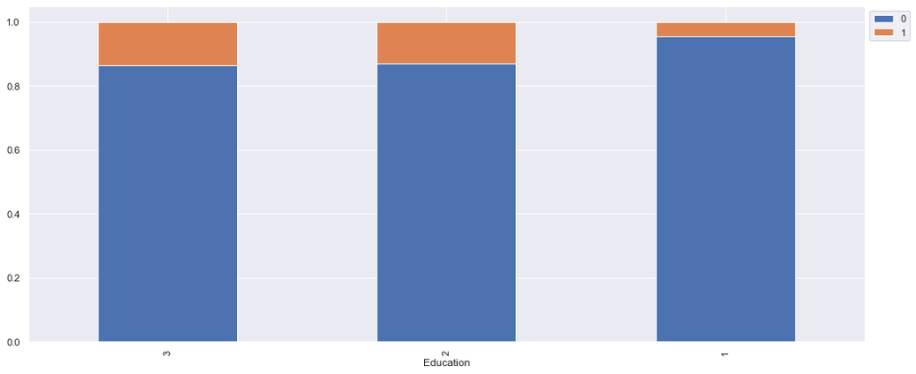

```python
stacked_plot(loan['Education'])
```

### Securities_Account Vs Personal_Loan

```
Personal_Loan          0    1   All
Securities_Account
All                 4520  480  5000
0                   4058  420  4478
1                    462   60   522
------------------------------------------------------------------------------------------------------------------------
```

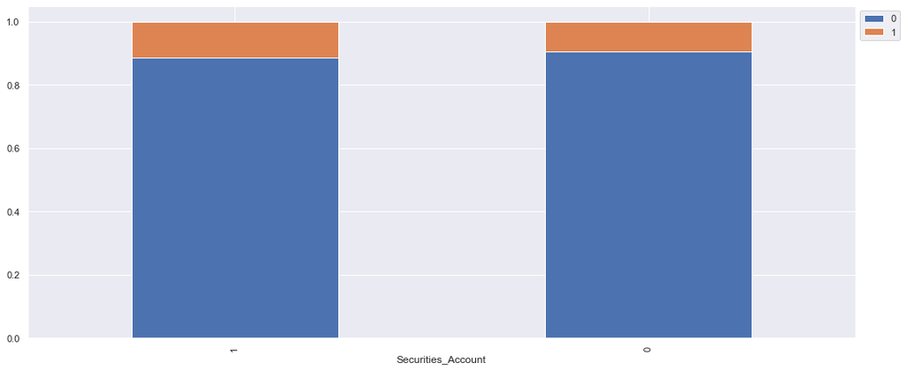

```python
stacked_plot(loan['Securities_Account'])
```

#### Observsations

No significant observations on custoemrs with Securities account who have signed up for personal loan

### CD_Account Vs Personal_Loan

```
Personal_Loan     0    1   All
CD_Account
All            4520  480  5000
0              4358  340  4698
1               162  140   302
------------------------------------------------------------------------------------------------------------------------
```

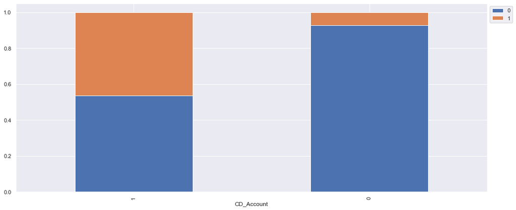

```python
stacked_plot(loan['CD_Account'])
```

#### Observations

A significantly higher proportion of customers CD Account have signed up for personal loan

### Online Vs Personal_Loan

```
Personal_Loan     0    1   All
Online
All            4520  480  5000
1              2693  291  2984
0              1827  189  2016
------------------------------------------------------------------------------------------------------------------------
```

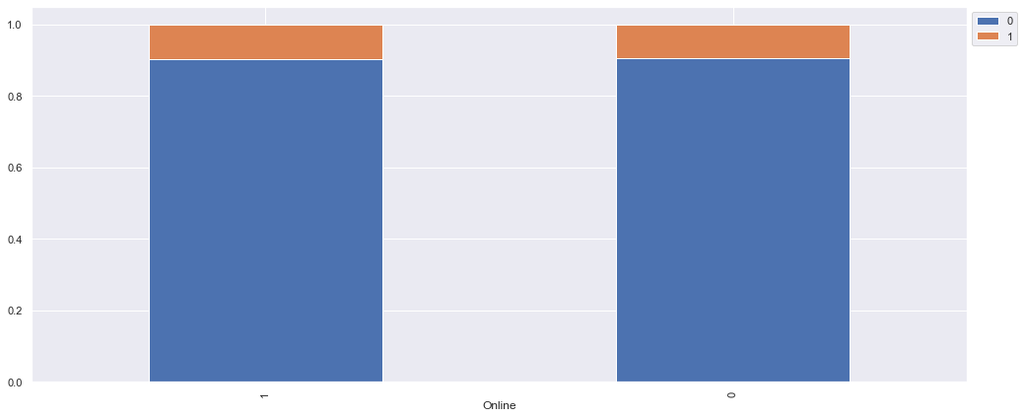

```python
stacked_plot(loan['Online'])
```

#### Observations

There is no significant trend to note

### CreditCard Vs Personal_Loan

```
Personal_Loan     0    1   All
CreditCard
All            4520  480  5000
0              3193  337  3530
1              1327  143  1470
------------------------------------------------------------------------------------------------------------------------
```

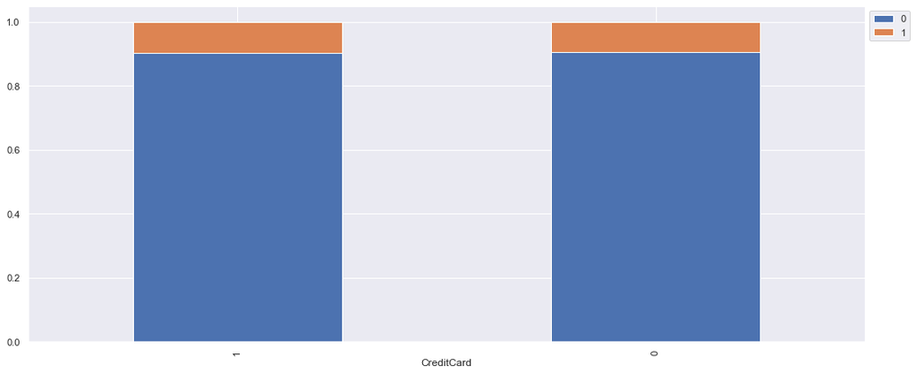

```python
stacked_plot(loan['CreditCard'])
```

#### Observations

There is no significant trend to note

## 3.4 Treating outliers

```python
def treat_outliers(data,col):
    '''
    treats outliers in a varaible
    col: str, name of the numerical varaible
    data: data frame
    col: name of the column
    '''
    Q1=data[col].quantile(0.25) # 25th quantile
    Q3=data[col].quantile(0.75)  # 75th quantile
    IQR=Q3-Q1
    Lower_Whisker = Q1 - 1.5*IQR
    Upper_Whisker = Q3 + 1.5*IQR
    data[col] = np.clip(data[col], Lower_Whisker, Upper_Whisker) # all the values samller than Lower_Whisker will be assigned value of Lower_whisker
                                                            # and all the values above upper_whishker will be assigned value of upper_Whisker
    return data

def treat_outliers_all(data, col_list):
    '''
    treat outlier in all numerical varaibles
    col_list: list of numerical varaibles
    data: data frame
    '''
    for c in col_list:
        data = treat_outliers(data,c)

    return data
```

```python
outliers_columns = ['Income','CCAvg','Mortgage']
loan = treat_outliers_all(loan,outliers_columns)
```

## 3.5 Data Prep

### Simplifying ZipCode

```python
# The first three digits of a zip code are more significant and representative of the collective wealth of zip codes

# Strip the last two digits
loan['ZIPSimple']=loan['ZIPCode']//100
loan.head(2)
```

|  | ID | Age | Experience | Income | ZIPCode | Family | CCAvg | Education | Mortgage | Personal_Loan | Securities_Account | CD_Account | Online | CreditCard | ZIPSimple |
| --- | --- | --- | --- | --- | --- | --- | --- | --- | --- | --- | --- | --- | --- | --- | --- |
| 0 | 1 | 25 | 1 | 49.0 | 91107 | 4 | 1.6 | 1 | 0.0 | 0 | 1 | 0 | 0 | 0 | 911 |
| 1 | 2 | 45 | 19 | 34.0 | 90089 | 3 | 1.5 | 1 | 0.0 | 0 | 1 | 0 | 0 | 0 | 900 |

### Set Education as categorical

```python
# Education - while encoded as a numeric - is really a categorical parameter

loan['Education'] = loan['Education'].astype('category')
```

### Remove rows with negative values for Experience

```python
# There is no way to normalize a negative experience. Therefore let's drop the rows with negative experience

loan.drop(loan[loan['Experience'] < 0].index, inplace=True)
loan.describe().T
```

|  | count | mean | std | min | 25% | 50% | 75% | max |
| --- | --- | --- | --- | --- | --- | --- | --- | --- |
| ID | 4948.0 | 2501.268795 | 1443.277676 | 1.0 | 1254.75 | 2497.5 | 3750.25 | 5000.0 |
| Age | 4948.0 | 45.557195 | 11.320735 | 24.0 | 36.00 | 46.0 | 55.00 | 67.0 |
| Experience | 4948.0 | 20.331043 | 11.311973 | 0.0 | 10.75 | 20.0 | 30.00 | 43.0 |
| Income | 4948.0 | 73.656023 | 45.701532 | 8.0 | 39.00 | 64.0 | 98.00 | 186.5 |
| ZIPCode | 4948.0 | 93168.503436 | 1761.076366 | 90005.0 | 91911.00 | 93437.0 | 94608.00 | 96651.0 |
| Family | 4948.0 | 2.391471 | 1.148444 | 1.0 | 1.00 | 2.0 | 3.00 | 4.0 |
| CCAvg | 4948.0 | 1.830051 | 1.454130 | 0.0 | 0.70 | 1.5 | 2.60 | 5.2 |
| Mortgage | 4948.0 | 50.590946 | 83.001051 | 0.0 | 0.00 | 0.0 | 101.00 | 252.5 |
| Personal_Loan | 4948.0 | 0.097009 | 0.296000 | 0.0 | 0.00 | 0.0 | 0.00 | 1.0 |
| Securities_Account | 4948.0 | 0.104285 | 0.305660 | 0.0 | 0.00 | 0.0 | 0.00 | 1.0 |
| CD_Account | 4948.0 | 0.061035 | 0.239418 | 0.0 | 0.00 | 0.0 | 0.00 | 1.0 |
| Online | 4948.0 | 0.597009 | 0.490549 | 0.0 | 0.00 | 1.0 | 1.00 | 1.0 |
| CreditCard | 4948.0 | 0.294058 | 0.455664 | 0.0 | 0.00 | 0.0 | 1.00 | 1.0 |
| ZIPSimple | 4948.0 | 931.355699 | 17.663396 | 900.0 | 919.00 | 934.0 | 946.00 | 966.0 |

#### Observations:

We are left with 52 fewer rows after dropping negative Experiences

### Let's check for multi-colinearity first

```python
# to compute VIF, we first have to add a constant column having value 1 to our input variables

X1 = loan.copy()
X1['const'] = 1
X1.head()
```

|  | ID | Age | Experience | Income | ZIPCode | Family | CCAvg | Education | Mortgage | Personal_Loan | Securities_Account | CD_Account | Online | CreditCard | ZIPSimple | const |
| --- | --- | --- | --- | --- | --- | --- | --- | --- | --- | --- | --- | --- | --- | --- | --- | --- |
| 0 | 1 | 25 | 1 | 49.0 | 91107 | 4 | 1.6 | 1 | 0.0 | 0 | 1 | 0 | 0 | 0 | 911 | 1 |
| 1 | 2 | 45 | 19 | 34.0 | 90089 | 3 | 1.5 | 1 | 0.0 | 0 | 1 | 0 | 0 | 0 | 900 | 1 |
| 2 | 3 | 39 | 15 | 11.0 | 94720 | 1 | 1.0 | 1 | 0.0 | 0 | 0 | 0 | 0 | 0 | 947 | 1 |
| 3 | 4 | 35 | 9 | 100.0 | 94112 | 1 | 2.7 | 2 | 0.0 | 0 | 0 | 0 | 0 | 0 | 941 | 1 |
| 4 | 5 | 35 | 8 | 45.0 | 91330 | 4 | 1.0 | 2 | 0.0 | 0 | 0 | 0 | 0 | 1 | 913 | 1 |

```python
from statsmodels.stats.outliers_influence import variance_inflation_factor

vif_series1 = pd.Series([variance_inflation_factor(X1.values,i) for i in range(X1.shape[1])],index=X1.columns)
print('VIF Series before feature selection: \n\n{}\n'.format(vif_series1))
```

```
VIF Series before feature selection:

ID                       1.003079
Age                     91.797175
Experience              91.672373
Income                   2.155460
ZIPCode               4477.253498
Family                   1.061330
CCAvg                    1.713488
Education                1.198872
Mortgage                 1.023855
Personal_Loan            1.646939
Securities_Account       1.146073
CD_Account               1.447999
Online                   1.043141
CreditCard               1.118056
ZIPSimple             4477.272632
const                 3418.288481
dtype: float64
```

#### Observations

1. There is a high correlation between Age and Experience. Lets try dropping one of them to check oif VIF improves.
2. We also know that ZIPSimple is an engineerd variable with high correlation to ZIPCode. Therefore, we can safely drop ZIPCode

```python
X1 = X1.drop(['Experience','ZIPCode'], axis=1)
```

```python
vif_series1 = pd.Series([variance_inflation_factor(X1.values,i) for i in range(X1.shape[1])],index=X1.columns)
print('VIF Series before feature selection: \n\n{}\n'.format(vif_series1))
```

```
VIF Series before feature selection:

ID                       1.002545
Age                      1.009438
Income                   2.152756
Family                   1.059019
CCAvg                    1.707632
Education                1.126487
Mortgage                 1.023354
Personal_Loan            1.645328
Securities_Account       1.145751
CD_Account               1.447522
Online                   1.043011
CreditCard               1.117834
ZIPSimple                1.004629
const                 2849.197500
dtype: float64
```

#### Observation:

Our new VIF scores reveal that is is a good idea to drop Experience. Therefore we will drop Experience in the model below

# 4. Logistic Regression

## 4.1 Helper functions

```python
##  Function to calculate different metric scores of the model - Accuracy, Recall and Precision
def get_metrics_score(model,train,test,train_y,test_y,flag=True):
    '''
    model : classifier to predict values of X

    '''
    # defining an empty list to store train and test results

    score_list=[]

    pred_train = model.predict(train)
    pred_test = model.predict(test)

    train_acc = accuracy_score(pred_train,train_y)
    test_acc = accuracy_score(pred_test,test_y)

    train_recall = recall_score(train_y,pred_train)
    test_recall = recall_score(test_y,pred_test)

    train_precision = precision_score(train_y,pred_train)
    test_precision = precision_score(test_y,pred_test)

    train_f1 = f1_score(train_y,pred_train)
    test_f1 = f1_score(test_y,pred_test)


    score_list.extend((train_acc,test_acc,train_recall,test_recall,train_precision,test_precision,train_f1,test_f1))

     # If the flag is set to True then only the following print statements will be dispayed. The default value is set to True.
    if flag == True:
        print("Accuracy on training set : ",accuracy_score(pred_train,train_y))
        print("Accuracy on test set : ",accuracy_score(pred_test,test_y))
        print("Recall on training set : ",recall_score(train_y,pred_train))
        print("Recall on test set : ",recall_score(test_y,pred_test))
        print("Precision on training set : ",precision_score(train_y,pred_train))
        print("Precision on test set : ",precision_score(test_y,pred_test))
        print("F1 on training set : ",f1_score(train_y,pred_train))
        print("F1 on test set : ",f1_score(test_y,pred_test))

    return score_list # returning the list with train and test scores
```

```python
def make_confusion_matrix(model,test_X,y_actual,labels=[1, 0]):
    '''
    model : classifier to predict values of X
    y_actual : ground truth

    '''
    y_predict = model.predict(test_X)
    cm=metrics.confusion_matrix( y_actual, y_predict, labels=[0, 1])
    df_cm = pd.DataFrame(cm, index = [i for i in ["Actually No (Loan) ","Actual Yes (Loan)"]],
                  columns = [i for i in ['Predicted No (Loan)','Predicted Yes (Loan)']])
    group_counts = ["{0:0.0f}".format(value) for value in
                cm.flatten()]
    group_percentages = ["{0:.2%}".format(value) for value in
                         cm.flatten()/np.sum(cm)]
    labels = [f"{v1}\n{v2}" for v1, v2 in
              zip(group_counts,group_percentages)]
    labels = np.asarray(labels).reshape(2,2)
    plt.figure(figsize = (10,7))
    sns.heatmap(df_cm, annot=labels,fmt='')
    plt.ylabel('True label')
    plt.xlabel('Predicted label')
```

## 4.2 Logistic regression model building

```python
# As we discovered during VIF calculations - it is a good idea to drop Experience inlieu of Age
# ID is not necessary for the model - therefore we will drop that variable as well
# ZIPSimple will replace ZIPCode - therefore ZIPCode can be dropped from the model

X = loan.drop(['ID', 'Experience','ZIPCode', 'Personal_Loan'],axis=1)
Y = loan['Personal_Loan']

# We converted Education as a categorical. Lets get dummies for this column
X = pd.get_dummies(X,drop_first=True)
feature_names = list(X.columns)

# Let's split test and train in a 30/70 ratio
X_train, X_test, y_train, y_test = train_test_split(X,Y, test_size=0.30, random_state = 1)
```

```python
# Let's confirm that the test/train split is really 30/70
y_test.value_counts()
```

```
0    1340
1     145
Name: Personal_Loan, dtype: int64
```

```python
y_train.value_counts()
```

```
0    3128
1     335
Name: Personal_Loan, dtype: int64
```

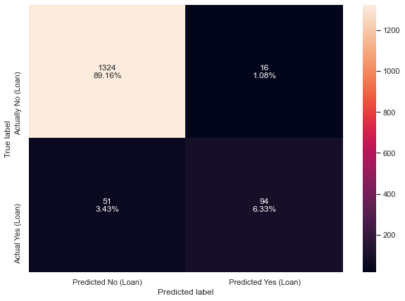

```python
# Build a Logistic Regressiopn
model = LogisticRegression(random_state=1)
lg = model.fit(X_train,y_train)

# creating confusion matrix
make_confusion_matrix(lg,X_test,y_test)
```

## 4.3 Model performance & Optimization

```python
scores_LR = get_metrics_score(lg,X_train,X_test,y_train,y_test,flag=True)
```

```
Accuracy on training set :  0.9610164597170083
Accuracy on test set :  0.9548821548821549
Recall on training set :  0.6925373134328359
Recall on test set :  0.6482758620689655
Precision on training set :  0.8787878787878788
Precision on test set :  0.8545454545454545
F1 on training set :  0.7746243739565943
F1 on test set :  0.7372549019607844
```

#### Observation

1. Since we want the model to predict how will potentially sign for a personal loan - we need to use recall as the masure of performannce.
2. Recall/Sensitivity in this case is (# of Personal_Loan predicted by model - i.e. TP)/((# of Personal_Loan predicted by model - i.e. TP) + (# of Personal_Loan Not predicted by model but actually signed up by customer - i.e. FN))
3. Recall or sensitivity is the right measure of success for this objective
4. Test and train data perform similarly - therefore it is fair to say that the model is not overfitting.
5. Although the model is not perfroming very well with a recall of 65%+

### Optimizing threshold

Let's try to optiimize the model performance with the aid of a ROC-AUC curve

#### ROC-AUC on training set

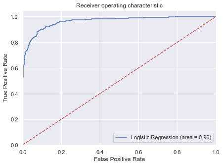

```python
logit_roc_auc_train = roc_auc_score(y_train, lg.predict_proba(X_train)[:,1])
fpr, tpr, thresholds = roc_curve(y_train, lg.predict_proba(X_train)[:,1])
plt.figure(figsize=(7,5))
plt.plot(fpr, tpr, label='Logistic Regression (area = %0.2f)' % logit_roc_auc_train)
plt.plot([0, 1], [0, 1],'r--')
plt.xlim([0.0, 1.0])
plt.ylim([0.0, 1.05])
plt.xlabel('False Positive Rate')
plt.ylabel('True Positive Rate')
plt.title('Receiver operating characteristic')
plt.legend(loc="lower right")
plt.show()
```

#### ROC-AUC on test set

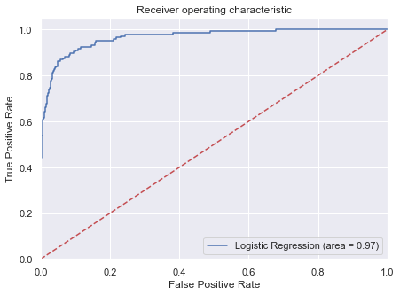

```python
logit_roc_auc_test = roc_auc_score(y_test, lg.predict_proba(X_test)[:,1])
fpr, tpr, thresholds = roc_curve(y_test, lg.predict_proba(X_test)[:,1])
plt.figure(figsize=(7,5))
plt.plot(fpr, tpr, label='Logistic Regression (area = %0.2f)' % logit_roc_auc_test)
plt.plot([0, 1], [0, 1],'r--')
plt.xlim([0.0, 1.0])
plt.ylim([0.0, 1.05])
plt.xlabel('False Positive Rate')
plt.ylabel('True Positive Rate')
plt.title('Receiver operating characteristic')
plt.legend(loc="lower right")
plt.show()
```

#### Finding the coefficients

```python
log_odds = lg.coef_[0]
pd.DataFrame(log_odds, X_train.columns, columns=['coef']).T
```

|  | Age | Income | Family | CCAvg | Mortgage | Securities_Account | CD_Account | Online | CreditCard | ZIPSimple | Education_2 | Education_3 |
| --- | --- | --- | --- | --- | --- | --- | --- | --- | --- | --- | --- | --- |
| coef | 0.012923 | 0.05847 | 0.603884 | 0.341961 | 0.001784 | 0.441575 | 2.553633 | -0.436245 | -0.603803 | -0.014641 | 3.318897 | 3.319462 |

#### Converting coefficients to odds

```python
change_odds = (np.exp(np.abs(lg.coef_[0]))-1)*100
pd.set_option('display.max_rows',None)
pd.DataFrame(change_odds, X_train.columns, columns=['odds']).T
```

|  | Age | Income | Family | CCAvg | Mortgage | Securities_Account | CD_Account | Online | CreditCard | ZIPSimple | Education_2 | Education_3 |
| --- | --- | --- | --- | --- | --- | --- | --- | --- | --- | --- | --- | --- |
| odds | 1.300688 | 6.021277 | 82.920896 | 40.770518 | 0.17855 | 55.515389 | 1185.37226 | 54.688738 | 82.906231 | 1.474891 | 2662.98497 | 2664.547691 |

##### Interpretations

1. Age: A unit chane in age of target customer increases the odds for personal loan by 1.3%
2. Income: A change of income by 1000 increases the odds for personal loan by 6%
3. CCAvg: A customer having an additional 1000 in credit card balance icnreases their odds by 40%
4. Securities_Account: A customer having a securities account increases their odds by 55%
5. CD_Account & Education have the maximum impact on the odds of signing up for personal loan

#### Optimal threshold using AUC-ROC curve

```python
# Let's see of f1 score can be improved further by changing the model threshold under the AUC-ROC curve
optimal_idx = np.argmax(tpr - fpr)
optimal_threshold = thresholds[optimal_idx]
print(optimal_threshold)
```

```
0.14016381033698094
```

```python
# Model prediction with optimal threshold

pred_train_opt = (lg.predict_proba(X_train)[:,1]>optimal_threshold)
pred_test_opt = (lg.predict_proba(X_test)[:,1]>optimal_threshold)

print('Accuracy on train data:',accuracy_score(y_train, pred_train_opt) )
print('Accuracy on test data:',accuracy_score(y_test, pred_test_opt))

print('Recall on train data:',recall_score(y_train, pred_train_opt) )
print('Recall on test data:',recall_score(y_test, pred_test_opt))

print('Precision on train data:',precision_score(y_train, pred_train_opt) )
print('Precision on test data:',precision_score(y_test, pred_test_opt))

print('F1 Score on train data:',f1_score(y_train, pred_train_opt) )
print('F1 Score on test data:',f1_score(y_test, pred_test_opt))

print('ROC-AUC Score on train data:',roc_auc_score(y_train, pred_train_opt) )
print('ROC-AUC Score on test data:',roc_auc_score(y_test, pred_test_opt))
```

```
Accuracy on train data: 0.9205890846087208
Accuracy on test data: 0.9265993265993266
Recall on train data: 0.8776119402985074
Recall on test data: 0.8758620689655172
Precision on train data: 0.5568181818181818
Precision on test data: 0.5825688073394495
F1 Score on train data: 0.6813441483198146
F1 Score on test data: 0.699724517906336
ROC-AUC Score on train data: 0.9014018780776425
ROC-AUC Score on test data: 0.9039758106021616
```

#### Let's use Precision-Recall curve and see if we can find a better threshold

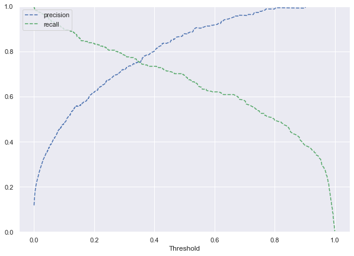

```python
# Let's see if we can further optimize the area under the ROC curve by plotting the recall and precisino values for a range of threshold values.
# We will try to pick a threshold value that maximizes the area

y_scores=lg.predict_proba(X_train)[:,1]
prec, rec, tre = precision_recall_curve(y_train, y_scores,)

def plot_prec_recall_vs_tresh(precisions, recalls, thresholds):
    plt.plot(thresholds, precisions[:-1], 'b--', label='precision')
    plt.plot(thresholds, recalls[:-1], 'g--', label = 'recall')
    plt.xlabel('Threshold')
    plt.legend(loc='upper left')
    plt.ylim([0,1])
plt.figure(figsize=(10,7))
plot_prec_recall_vs_tresh(prec, rec, tre)
plt.show()
```

1. Around a threshold value of 0.375 - the curve indicates a possible optimum value.
2. Let's plug that value and predict model performance and evaluate the ensuing results

```python
optimal_threshold = 0.375

# Model prediction with optimal threshold
pred_train_opt = (lg.predict_proba(X_train)[:,1]>optimal_threshold)
pred_test_opt = (lg.predict_proba(X_test)[:,1]>optimal_threshold)

#Model performance with optimal threhold

print('Accuracy on train data:',accuracy_score(y_train, pred_train_opt) )
print('Accuracy on test data:',accuracy_score(y_test, pred_test_opt))

print('Recall on train data:',recall_score(y_train, pred_train_opt))
print('Recall on test data:',recall_score(y_test, pred_test_opt))

print('Precision on train data:',precision_score(y_train, pred_train_opt) )
print('Precision on test data:',precision_score(y_test, pred_test_opt))

print('F1 Score on train data:',f1_score(y_train, pred_train_opt) )
print('F1 Score on test data:',f1_score(y_test, pred_test_opt))

print('ROC-AUC Score on train data:',roc_auc_score(y_train, pred_train_opt) )
print('ROC-AUC Score on test data:',roc_auc_score(y_test, pred_test_opt))
```

```
Accuracy on train data: 0.9552411204158244
Accuracy on test data: 0.9528619528619529
Recall on train data: 0.7402985074626866
Recall on test data: 0.7241379310344828
Precision on train data: 0.7848101265822784
Precision on test data: 0.7777777777777778
F1 Score on train data: 0.761904761904762
F1 Score on test data: 0.75
ROC-AUC Score on train data: 0.859279688513952
ROC-AUC Score on test data: 0.8508749356664951
```

## 5. DecisionTree Classifier Model

1. We will build a DecisionTreeClassifier function using the default gini criteria to split
2. The Frequency of the classes will be split in a 15-85 ratio

```python
tree_model = DecisionTreeClassifier(criterion='gini',class_weight={0:0.15,1:0.85},random_state=1)
```

```python
tree_model.fit(X_train, y_train)
```

```
DecisionTreeClassifier(class_weight={0: 0.15, 1: 0.85}, random_state=1)
```

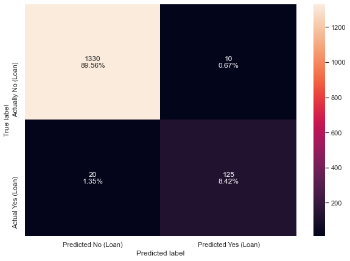

```python
make_confusion_matrix(tree_model,X_test,y_test)
```

```python
scores_DT = get_metrics_score(tree_model,X_train,X_test,y_train,y_test,flag=True)
```

```
Accuracy on training set :  1.0
Accuracy on test set :  0.9797979797979798
Recall on training set :  1.0
Recall on test set :  0.8620689655172413
Precision on training set :  1.0
Precision on test set :  0.9259259259259259
F1 on training set :  1.0
F1 on test set :  0.8928571428571429
```

## 5.1 Visualizing the tree

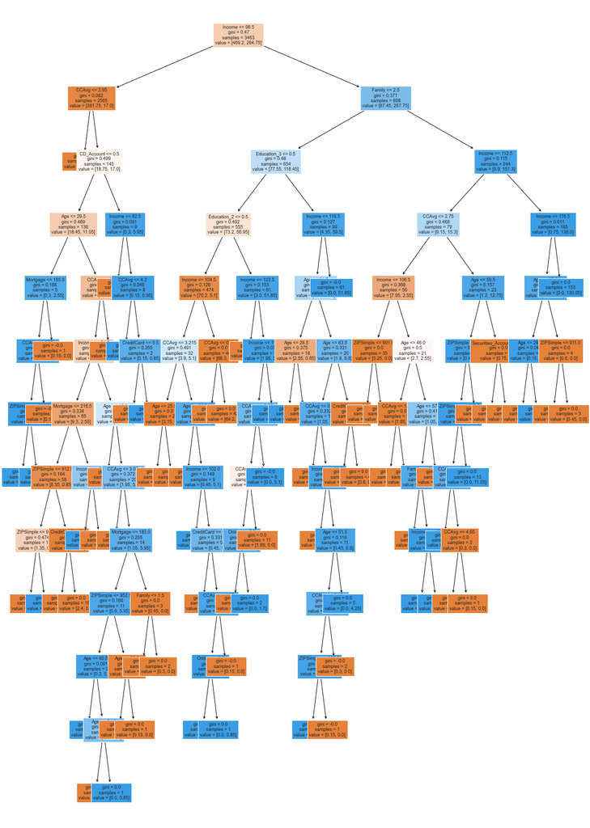

```python
plt.figure(figsize=(20,30))
out = tree.plot_tree(tree_model,feature_names=feature_names,filled=True,fontsize=9,node_ids=False,class_names=None,)
#below code will add arrows to the decision tree split if they are missing
for o in out:
     arrow = o.arrow_patch
     if arrow is not None:
        arrow.set_edgecolor('black')
        arrow.set_linewidth(1)
plt.show()
```

```python
print(tree.export_text(tree_model,feature_names=feature_names,show_weights=True))
```

```
|--- Income <= 96.50
|   |--- CCAvg <= 2.95
|   |   |--- weights: [363.00, 0.00] class: 0
|   |--- CCAvg >  2.95
|   |   |--- CD_Account <= 0.50
|   |   |   |--- Age <= 29.50
|   |   |   |   |--- Mortgage <= 155.00
|   |   |   |   |   |--- CCAvg <= 4.55
|   |   |   |   |   |   |--- ZIPSimple <= 923.50
|   |   |   |   |   |   |   |--- weights: [0.00, 0.85] class: 1
|   |   |   |   |   |   |--- ZIPSimple >  923.50
|   |   |   |   |   |   |   |--- weights: [0.00, 1.70] class: 1
|   |   |   |   |   |--- CCAvg >  4.55
|   |   |   |   |   |   |--- weights: [0.15, 0.00] class: 0
|   |   |   |   |--- Mortgage >  155.00
|   |   |   |   |   |--- weights: [0.15, 0.00] class: 0
|   |   |   |--- Age >  29.50
|   |   |   |   |--- CCAvg <= 4.20
|   |   |   |   |   |--- Income <= 81.50
|   |   |   |   |   |   |--- Mortgage <= 216.50
|   |   |   |   |   |   |   |--- ZIPSimple <= 912.50
|   |   |   |   |   |   |   |   |--- ZIPSimple <= 909.00
|   |   |   |   |   |   |   |   |   |--- weights: [1.35, 0.00] class: 0
|   |   |   |   |   |   |   |   |--- ZIPSimple >  909.00
|   |   |   |   |   |   |   |   |   |--- weights: [0.00, 0.85] class: 1
|   |   |   |   |   |   |   |--- ZIPSimple >  912.50
|   |   |   |   |   |   |   |   |--- CreditCard <= 0.50
|   |   |   |   |   |   |   |   |   |--- weights: [4.80, 0.00] class: 0
|   |   |   |   |   |   |   |   |--- CreditCard >  0.50
|   |   |   |   |   |   |   |   |   |--- weights: [2.40, 0.00] class: 0
|   |   |   |   |   |   |--- Mortgage >  216.50
|   |   |   |   |   |   |   |--- Income <= 68.00
|   |   |   |   |   |   |   |   |--- weights: [0.00, 1.70] class: 1
|   |   |   |   |   |   |   |--- Income >  68.00
|   |   |   |   |   |   |   |   |--- weights: [0.75, 0.00] class: 0
|   |   |   |   |   |--- Income >  81.50
|   |   |   |   |   |   |--- Age <= 46.00
|   |   |   |   |   |   |   |--- weights: [2.55, 0.00] class: 0
|   |   |   |   |   |   |--- Age >  46.00
|   |   |   |   |   |   |   |--- CCAvg <= 3.05
```

[output cut: 156 more lines]

```
|   |   |   |   |   |   |--- weights: [0.15, 0.00] class: 0
|   |   |--- Income >  112.50
|   |   |   |--- Income <= 116.50
|   |   |   |   |--- Age <= 55.50
|   |   |   |   |   |--- Age <= 29.00
|   |   |   |   |   |   |--- weights: [0.15, 0.00] class: 0
|   |   |   |   |   |--- Age >  29.00
|   |   |   |   |   |   |--- weights: [0.00, 5.95] class: 1
|   |   |   |   |--- Age >  55.50
|   |   |   |   |   |--- ZIPSimple <= 911.00
|   |   |   |   |   |   |--- weights: [0.15, 0.00] class: 0
|   |   |   |   |   |--- ZIPSimple >  911.00
|   |   |   |   |   |   |--- weights: [0.45, 0.00] class: 0
|   |   |   |--- Income >  116.50
|   |   |   |   |--- weights: [0.00, 130.05] class: 1
```

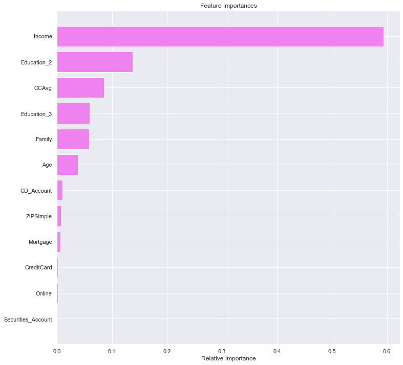

```python
importances = tree_model.feature_importances_
indices = np.argsort(importances)

plt.figure(figsize=(12,12))
plt.title('Feature Importances')
plt.barh(range(len(indices)), importances[indices], color='violet', align='center')
plt.yticks(range(len(indices)), [feature_names[i] for i in indices])
plt.xlabel('Relative Importance')
plt.show()
```

```python
# importance of features in the tree building ( The importance of a feature is computed as the
#(normalized) total reduction of the criterion brought by that feature. It is also known as the Gini importance )

print (pd.DataFrame(tree_model.feature_importances_, columns = ["Imp"], index = X_train.columns).sort_values(by = 'Imp', ascending = False))
```

```
                             Imp
Income              5.937687e-01
Education_2         1.379171e-01
CCAvg               8.538847e-02
Education_3         5.906151e-02
Family              5.838565e-02
Age                 3.807624e-02
CD_Account          9.703671e-03
ZIPSimple           7.640260e-03
Mortgage            6.669828e-03
CreditCard          1.949570e-03
Online              1.439001e-03
Securities_Account  1.010254e-17
```

#### Insights

1. The current decision tree is clearly overfitting as evidenced by the perfect recall scores.
2. We will use the GridSearch algorithm to search for an optimum tree classification

## 5.2 Reducing Overfitting (GridSearch)

```python
# Choose the type of classifier.
estimator = DecisionTreeClassifier(random_state=1,class_weight = {0:0.15,1:0.85})

# Grid of parameters to choose from
parameters = {
            'max_depth': np.arange(1,10),
            'criterion': ['entropy','gini'],
            'splitter': ['best','random'],
            'min_impurity_decrease': [0.000001,0.00001,0.0001],
            'max_features': ['log2','sqrt']
             }

# Type of scoring used to compare parameter combinations
scorer = metrics.make_scorer(metrics.recall_score)

# Run the grid search
grid_obj = GridSearchCV(estimator, parameters, scoring=scorer,cv=5)
grid_obj = grid_obj.fit(X_train, y_train)

# Set the clf to the best combination of parameters
estimator = grid_obj.best_estimator_

# Fit the best algorithm to the data.
estimator.fit(X_train, y_train)
```

```
DecisionTreeClassifier(class_weight={0: 0.15, 1: 0.85}, criterion='entropy',
                       max_depth=2, max_features='log2',
                       min_impurity_decrease=1e-06, random_state=1)
```

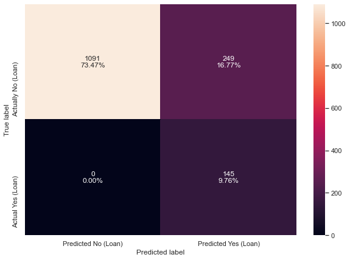

```python
make_confusion_matrix(estimator,X_test,y_test)
```

```python
scores_hyper_DT = get_metrics_score(tree_model,X_train,X_test,y_train,y_test,flag=True)
```

```
Accuracy on training set :  1.0
Accuracy on test set :  0.9797979797979798
Recall on training set :  1.0
Recall on test set :  0.8620689655172413
Precision on training set :  1.0
Precision on test set :  0.9259259259259259
F1 on training set :  1.0
F1 on test set :  0.8928571428571429
```

### Visualizing the new tree

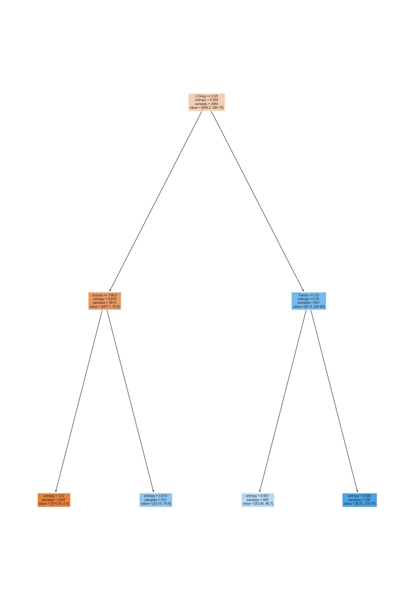

```python
plt.figure(figsize=(20,30))
out = tree.plot_tree(estimator,feature_names=feature_names,filled=True,fontsize=9,node_ids=False,class_names=None,)
#below code will add arrows to the decision tree split if they are missing
for o in out:
     arrow = o.arrow_patch
     if arrow is not None:
        arrow.set_edgecolor('black')
        arrow.set_linewidth(1)
plt.show()
```

```python
# Text report showing the rules of a decision tree -

print(tree.export_text(estimator,feature_names=feature_names,show_weights=True))
```

```
|--- CCAvg <= 2.95
|   |--- Income <= 106.50
|   |   |--- weights: [374.55, 0.00] class: 0
|   |--- Income >  106.50
|   |   |--- weights: [33.15, 79.90] class: 1
|--- CCAvg >  2.95
|   |--- Family <= 2.50
|   |   |--- weights: [52.95, 86.70] class: 1
|   |--- Family >  2.50
|   |   |--- weights: [8.55, 118.15] class: 1
```

```python
print (pd.DataFrame(estimator.feature_importances_, columns = ["Imp"], index = X_train.columns).sort_values(by = 'Imp', ascending = False))
```

```
                         Imp
Income              0.484941
CCAvg               0.450193
Family              0.064866
Age                 0.000000
Mortgage            0.000000
Securities_Account  0.000000
CD_Account          0.000000
Online              0.000000
CreditCard          0.000000
ZIPSimple           0.000000
Education_2         0.000000
Education_3         0.000000
```

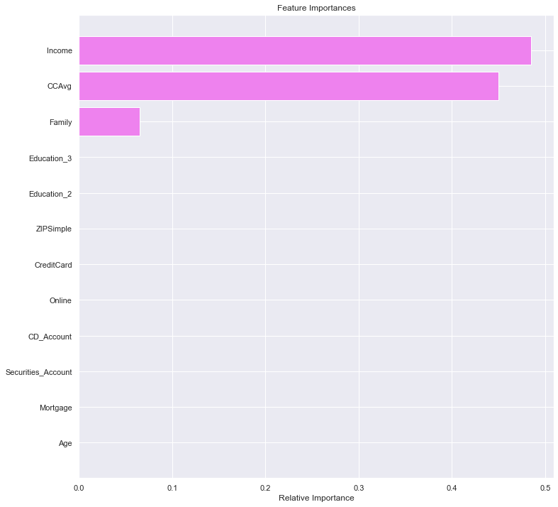

```python
importances = estimator.feature_importances_
indices = np.argsort(importances)

plt.figure(figsize=(12,12))
plt.title('Feature Importances')
plt.barh(range(len(indices)), importances[indices], color='violet', align='center')
plt.yticks(range(len(indices)), [feature_names[i] for i in indices])
plt.xlabel('Relative Importance')
plt.show()
```

## 5.3 Cost complexity pruning

```python
clf = DecisionTreeClassifier(random_state=1,class_weight = {0:0.15,1:0.85})
path = clf.cost_complexity_pruning_path(X_train, y_train)
ccp_alphas, impurities = path.ccp_alphas, path.impurities
```

##### We are looking for the smalest effective alpha value. Higher alpha value leads to more pruning and vice-versa.

```python
pd.DataFrame(path)
```

|  | ccp_alphas | impurities |
| --- | --- | --- |
| 0 | 0.000000e+00 | -6.681122e-15 |
| 1 | 1.325288e-19 | -6.680989e-15 |
| 2 | 7.509964e-19 | -6.680238e-15 |
| 3 | 7.509964e-19 | -6.679487e-15 |
| 4 | 7.509964e-19 | -6.678736e-15 |
| 5 | 1.767050e-18 | -6.676969e-15 |
| 6 | 2.429694e-18 | -6.674539e-15 |
| 7 | 2.650576e-18 | -6.671889e-15 |
| 8 | 3.534101e-18 | -6.668355e-15 |
| 9 | 4.240921e-18 | -6.664114e-15 |
| 10 | 4.748948e-18 | -6.659365e-15 |
| 11 | 5.411592e-18 | -6.653953e-15 |
| 12 | 5.853354e-18 | -6.648100e-15 |
| 13 | 1.206012e-17 | -6.636040e-15 |
| 14 | 5.662513e-16 | -6.069789e-15 |
| 15 | 1.940599e-04 | 3.881198e-04 |
| 16 | 3.560197e-04 | 1.100159e-03 |
| 17 | 3.656419e-04 | 1.465801e-03 |
| 18 | 3.656419e-04 | 2.197085e-03 |
| 19 | 3.656419e-04 | 3.659652e-03 |
| 20 | 3.694901e-04 | 4.029142e-03 |
| 21 | 3.788050e-04 | 4.786752e-03 |
| 22 | 3.843394e-04 | 5.939771e-03 |
| 23 | 3.881198e-04 | 6.327890e-03 |
| 24 | 6.375294e-04 | 6.965420e-03 |
| 25 | 6.764374e-04 | 7.641857e-03 |
| 26 | 6.882105e-04 | 8.330068e-03 |
| 27 | 7.120394e-04 | 9.042107e-03 |
| 28 | 7.952453e-04 | 1.063260e-02 |
| 29 | 9.217105e-04 | 1.155431e-02 |
| 30 | 9.502030e-04 | 1.250451e-02 |
| 31 | 1.025450e-03 | 1.455541e-02 |
| 32 | 1.260903e-03 | 1.581632e-02 |
| 33 | 1.362694e-03 | 1.717901e-02 |
| 34 | 1.380485e-03 | 1.855949e-02 |
| 35 | 1.436277e-03 | 2.286832e-02 |
| 36 | 1.505879e-03 | 2.437420e-02 |
| 37 | 1.528406e-03 | 2.590261e-02 |
| 38 | 1.642777e-03 | 2.754539e-02 |
| 39 | 1.691094e-03 | 2.923648e-02 |
| 40 | 1.756390e-03 | 3.099287e-02 |
| 41 | 1.877364e-03 | 3.287023e-02 |
| 42 | 1.889699e-03 | 3.475993e-02 |
| 43 | 2.050528e-03 | 4.091152e-02 |
| 44 | 2.264290e-03 | 4.317581e-02 |
| 45 | 2.537554e-03 | 4.571336e-02 |
| 46 | 3.396820e-03 | 4.911018e-02 |
| 47 | 4.128003e-03 | 5.323819e-02 |
| 48 | 4.561448e-03 | 5.779963e-02 |
| 49 | 6.750001e-03 | 6.454963e-02 |
| 50 | 7.157712e-03 | 7.170735e-02 |
| 51 | 7.481515e-03 | 7.918886e-02 |
| 52 | 1.952159e-02 | 9.871045e-02 |
| 53 | 3.977605e-02 | 2.180386e-01 |
| 54 | 2.520358e-01 | 4.700744e-01 |

##### Total leaf impurity vs effective alphas of pruned tree

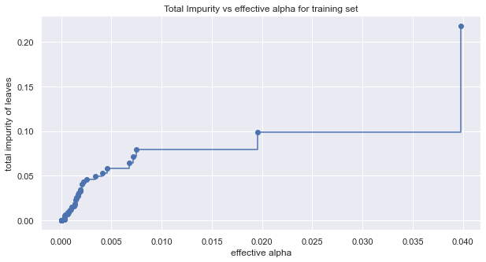

```python
fig, ax = plt.subplots(figsize=(10,5))
ax.plot(ccp_alphas[:-1], impurities[:-1], marker='o', drawstyle="steps-post")
ax.set_xlabel("effective alpha")
ax.set_ylabel("total impurity of leaves")
ax.set_title("Total Impurity vs effective alpha for training set")
plt.show()
```

##### We now train a tree using effecgive alphas. The Last alpha prunes the most.

```python
clfs = []
for ccp_alpha in ccp_alphas:
    clf = DecisionTreeClassifier(random_state=1, ccp_alpha=ccp_alpha,class_weight = {0:0.15,1:0.85})
    clf.fit(X_train, y_train)
    clfs.append(clf)
print("Number of nodes in the last tree is: {} with ccp_alpha: {}".format(
      clfs[-1].tree_.node_count, ccp_alphas[-1]))
```

```
Number of nodes in the last tree is: 1 with ccp_alpha: 0.25203583584710654
```

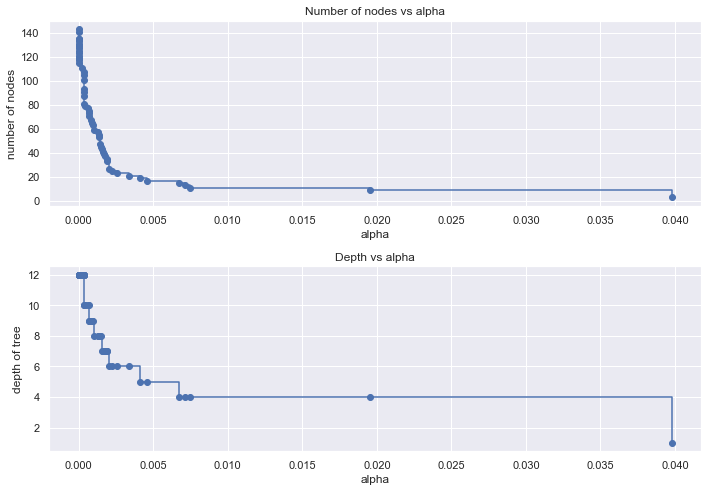

```python
clfs = clfs[:-1]
ccp_alphas = ccp_alphas[:-1]

node_counts = [clf.tree_.node_count for clf in clfs]
depth = [clf.tree_.max_depth for clf in clfs]
fig, ax = plt.subplots(2, 1,figsize=(10,7))
ax[0].plot(ccp_alphas, node_counts, marker='o', drawstyle="steps-post")
ax[0].set_xlabel("alpha")
ax[0].set_ylabel("number of nodes")
ax[0].set_title("Number of nodes vs alpha")
ax[1].plot(ccp_alphas, depth, marker='o', drawstyle="steps-post")
ax[1].set_xlabel("alpha")
ax[1].set_ylabel("depth of tree")
ax[1].set_title("Depth vs alpha")
fig.tight_layout()
```

```python
recall_train=[]
for clf in clfs:
    pred_train3=clf.predict(X_train)
    values_train=metrics.recall_score(y_train,pred_train3)
    recall_train.append(values_train)
```

```python
recall_test=[]
for clf in clfs:
    pred_test3=clf.predict(X_test)
    values_test=metrics.recall_score(y_test,pred_test3)
    recall_test.append(values_test)
```

```python
train_scores = [clf.score(X_train, y_train) for clf in clfs]
test_scores = [clf.score(X_test, y_test) for clf in clfs]
```

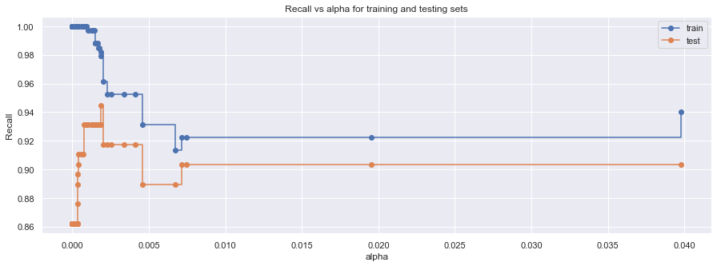

```python
fig, ax = plt.subplots(figsize=(15,5))
ax.set_xlabel("alpha")
ax.set_ylabel("Recall")
ax.set_title("Recall vs alpha for training and testing sets")
ax.plot(ccp_alphas, recall_train, marker='o', label="train",
        drawstyle="steps-post",)
ax.plot(ccp_alphas, recall_test, marker='o', label="test",
        drawstyle="steps-post")
ax.legend()
plt.show()
```

```python
# creating the model where we get highest train and test recall
index_best_model = np.argmax(recall_test)
best_model = clfs[index_best_model]
print(best_model)
```

```
DecisionTreeClassifier(ccp_alpha=0.001889698749377399,
                       class_weight={0: 0.15, 1: 0.85}, random_state=1)
```

```python
best_model.fit(X_train, y_train)
```

```
DecisionTreeClassifier(ccp_alpha=0.001889698749377399,
                       class_weight={0: 0.15, 1: 0.85}, random_state=1)
```

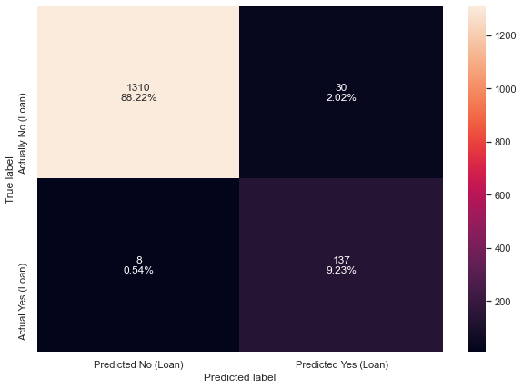

```python
make_confusion_matrix(best_model,X_test,y_test)
```

```python
scores_best_DT = get_metrics_score(best_model,X_train,X_test,y_train,y_test,flag=True)
```

```
Accuracy on training set :  0.9760323419000866
Accuracy on test set :  0.9744107744107744
Recall on training set :  0.982089552238806
Recall on test set :  0.9448275862068966
Precision on training set :  0.8103448275862069
Precision on test set :  0.8203592814371258
F1 on training set :  0.8879892037786775
F1 on test set :  0.8782051282051282
```